# Assignment 2: Solar panel simulation

Programming for Engineers (ENGG1001)  
**Due: 23 October 2026, 16:00 GMT+10**

Published

September 28, 2026

# Introduction

The Australian Government has legislated a national target of reducing greenhouse gas emissions by 43% below 2005 levels by 2030, and net zero emissions by 2050 as part of global efforts to avoid the worst effects of climate change [DCCEEW](https://www.dcceew.gov.au/climate-change/emissions-reduction). Achieving these targets requires decarbonisation of the energy sector, transitioning from fossil fuels to renewable energy technologies, such as solar photovoltaics (PV). Rooftop solar accounted for 12.4 % of the Australian energy mix in 2024, up from 6.5 % in 2020. Quantifying solar panel performance, and associated emissions reductions and cost savings, is important for assessing and comparing the impact of choosing different technology options.

This assignment refines and applies the simple model used Assignment 1, using numpy arrays and object oriented programming to build and apply a simple solar panel model. You will calculate solar panel output over an annual cycle and quantify associated emissions reductions for different technology choices. The model is simplified for the purposes of the assignment, but demonstrates how programming is used to build, refine and communicate engineering models for decision-making.

**Caution**

**Debugging is an essential part of programming**, and is most efficient if you find ways to test and check your code, and the results from your code, as you go. This is an important skill for all engineering problem-solving, as engineers need to find ways to check if their work is correct.

1. Start testing in Gradescope as soon as you have written your first function.
2. Build up your code by adding one function at a time, ensuring each function is correct before you add a new one. Get each new function running in IDLE first, then test your updated code into Gradescope.
3. Expect to encounter errors when you add a new function. To find the source of each error, use the error message to find the line where the error occurs. Test individual lines of code in the console to narrow down what is (and isn’t) working. Inserting print statements within the function can help you see what is happening, and locate and resolve the bug.
4. Once your code is running, check if the answers are correct. Code can run but produce incorrect answers! e.g. check that the arrays returned are the size and shape you expect, check numerical values are reasonable: where possible, find a way to cross-check your answer.
5. Once your function is running in IDLE and you are reasonably confident it is producing correct results, **then test in Gradescope**. You will likely find more errors, and do more debugging!
6. Once your code is working in Gradescope, add the next function to your code, run your code in IDLE, debug, check the results, then test it in Gradescope. Keep going until your assignment is done!
7. Use a systematic approach to naming and saving your files, so you can find earlier versions

Please download the following template python file to get started:

```
a2.py
```

```python
import numpy as np
import matplotlib.pyplot as plt

__author__ = "Your Name"
__email__ = "Your Email"
__date__ = "Submission Date"

# write your code here!

if __name__ == "__main__":
    # test your code here!
    pass
```

## Part A: Modelling and analysis with arrays

### Task 1 : Sun angle from sunrise to sunset (1 mark)

Write a function `angle_of_sun(sunrise_time)` which returns an array containing the sun angle in degrees in 10 minute intervals between sunrise and sunset, and an array of the same size which contains time in 10 minute intervals from sunrise to sunset, represented as minutes since midnight.

Assume that the angle is zero at sunrise, 90 degrees at noon and 180 degrees at sunset, and that the day is symmetric around noon (i.e. the time between sunrise and noon is the same at the time between noon and sunset).

Sunrise time `sunrise_time` is provided as a tuple, where the first element is hour and the second element is minutes, e.g. 6:30~am is written as (6,30), 5:45~am is written as (5,45), and minutes are in multiples of 5. The function description is shown below:

```python
def angle_of_sun(sunrise_time: tuple[int, int]) -> tuple[np.ndarray, np.ndarray]:
    """Generates arrays of sun angle and minutes since midnight between the given sunrise time
    and sunset.

    Parameters
    ----------
    sunrise_time : tuple[int, int]
        The time of sunrise in the format (hours, minutes)

    Returns
    -------
    tuple[np.ndarray, np.ndarray]
        Returns two arrays (times, sun angles) with elements separated by 10
        minute intervals. The sun angle is measured in degrees. Time is
        represented in minutes since midnight, starting at sunrise and ending at the
        symmetric sunset (e.g., 6:30am -> 5:30pm, or 390 -> 1050 in minutes).
    """
```

A sample usage of the function is shown below:

sunrise_time = (6,0)

min_array, sun_array = angle_of_sun(sunrise_time)

min_array.size

73

sun_array.size

73

min_array[0:5]

array([360, 370, 380, 390, 400])

min_array[-5:]

array([1040, 1050, 1060, 1070, 1080])

sun_array[0:5]

array([ 0. , 2.5, 5. , 7.5, 10. ])

sun_array[-5:]

array([170. , 172.5, 175. , 177.5, 180. ])

### Task 2 : Daily sun intensity (1 mark)

Write a function `daily_intensity()` which has no arguments and returns an array containing the daily maximum sun intensity in units kWm$^{-2}$ for each day in a non-leap year in the Southern hemisphere, according to the equation:
$$\text{max daily intensity} = 1 - \frac{\text{days from summer solstice}}{480}
\tag{1}$$
where the summer solstice in the Southern hemisphere is assumed to occur on 21 December. Note that this quantity was called “yearly intensity” in Assignment 1, because it represents the way in which sun intensity changes over the year. We use a simplified model in this assignment… in reality, day length and sun intensity will both vary with latitude and with time of year. For the rest of this assignment, we use this simplified model and use “year” to refer to any non-leap year in the Southern hemisphere. The function description is shown below:

```python
def daily_intensity() -> np.ndarray[float]:
   """
    Determines sun intensity for each day in a Southern hemisphere non-leap year
    Returns
    -------
    np.ndarray[float]
        Maximum daily sun intensity in units kWm-2
        for each day in a non-leap year,
        based on distance of each day from summer solstice.
    """
```

A sample usage of the function is shown below:

daily_intensities = daily_intensity()

daily_intensities.size

365

daily_intensities[0:5]

array([0.97708333, 0.975 , 0.97291667, 0.97083333, 0.96875 ])

daily_intensities[-5:]

array([0.9875 , 0.98541667, 0.98333333, 0.98125 , 0.97916667])

**Caution**

We are assuming that the number of days in a year for Part A is 365!

### Task 3 : Intensity of sunlight hitting the solar panel (1 mark)

In Assignment 1, you calculated `incoming sunlight`. Here we use the same equation to calculate the intensity of light hitting the panel (`panel_intensity`, kWm$^{-2}$). The intensity of light hitting the panel depends on the maximum daily sun intensity (`max_daily_intensity`, kWm$^{-2}$), the angle of the sun (`sun_angle`, degrees) as it changes through the day determined from `angle_of_sun` and the incident angle `incident_angle`:
$$\text{panel\_intensity} = \text{max\_daily\_intensity} \times \cos{(\text{incident\_angle})} \times \sin{(\text{sun\_angle})}
\tag{2}$$
where the incident angle `incident_angle` is the angle between the incoming sunlight (`sun_angle`) and the angle perpendicular to the panel (`panel_angle` + 90) as follows, with all angles in degrees:
$$\text{incident\_angle} = \text{sun\_angle} - \text{panel\_angle} - 90
\tag{3}$$

The physical interpretation of Equation 3 is as follows:

1. When `incident_angle` = 0 degrees, it means that the sunlight is hitting perpendicular to the panel and therefore produces the maximum possible panel intensity;
2. If `incident_angle` < -90 degrees or `incident_angle` > 90 degrees, it indicates that no sunlight is hitting the panel.

Therefore, the incident angle calculated from Equation 3 must be capped to the range -90 to 90 degrees to ensure non-negative values of the intensity of sunlight hitting the solar panel.

Write a function `calc_panel_intensity(sunrise_time, panel_angle)` that takes in the sunrise time `sunrise_time`, and the panel angle `panel_angle` in degrees, returns a 2-d array containing the intensity of sunlight kWm$^{-2}$ hitting the solar panel at 10 minute intervals from sunrise to sunset (in rows), for each day in the year (in columns). The function description is shown below:

```python
def calc_panel_intensity(sunrise_time, panel_angle):
    """
    Calculates the intensity of sunlight hitting the solar panel at 10 minute intervals from sunrise to sunset.
    """
```

A sample usage of the function is shown below:

panel_intensities = calc_panel_intensity((6,0), 0)

panel_intensities.shape

(73, 365)

panel_intensities[:3, :3]

array([[0. , 0. , 0. ],

[0.00185905, 0.00185508, 0.00185112],

[0.00742205, 0.00740622, 0.0073904 ]])

panel_intensities[-3:, -3:]

array([[7.46952144e-03, 7.45369618e-03, 7.43787092e-03],

[1.87094010e-03, 1.86697625e-03, 1.86301239e-03],

[7.37381893e-33, 7.35819643e-33, 7.34257394e-33]])

panel_intensities = calc_panel_intensity((6,0), 30)

panel_intensities[:3, :3]

array([[0.00000000e+00, 0.00000000e+00, 0.00000000e+00],

[2.60970864e-18, 2.60414423e-18, 2.59857982e-18],

[5.21444955e-18, 5.20333132e-18, 5.19221309e-18]])

panel_intensities[10:13, 0:3]

array([[2.52848698e-17, 2.52309574e-17, 2.51770451e-17],

[2.76260034e-17, 2.75670994e-17, 2.75081953e-17],

[2.99145494e-17, 2.98507657e-17, 2.97869820e-17]])

**Caution**

Note that the docstring provided for this function is only half-complete. You will need to add a full description of the parameters and return values, as well as any other relevant information. Ensure that you match the required style as described in the style rubric!

### Task 4 : Daily panel input, output and avoided emissions (1 mark)

In Assignment 1, you modelled panel efficiency as a function of incoming sunlight, and found it was approximately 20%. Here we modify the model to account for both the base efficiency of the panel (`base_efficiency`) in converting sunlight to DC (direct current) power, and the efficiency of the inverter at converting DC to AC (`inverter_efficiency`). Both panel and inverter efficiency are treated as constants in Part A, and in Part~B you will refine this model to predict decline in panel efficiency as the panel ages. In this assignment, all efficiencies are written as proportions rather than percentage, to avoid unit errors and unnecessary conversions.

Power output for a 1~m $\times$ 1~m panel is determined from the intensity of sunlight hitting the panel (in kWm$^{-2}$), the panel area (1~m$^{2}$), the base efficiency of the panel (`base_efficiency`) and the inverter efficiency (`inverter_efficiency`) as follows:

$$\text{power}\ [\text{kW}] = \text{panel\_intensity}\ [\text{kW m}^{-2}] \times 1\ [\text{m}^{2}] \times \text{efficiency}_{\text{base}} \times \text{efficiency}_{\text{inverter}}
\tag{4}$$

The energy($kWh$) generated in a 10 minute period will depend on the power output as follows:

$$\text{energy} = \text{power} [\text{kW}] \times \frac{10 [\text{min}]}{60 [\text{min h}^{-1}]} \tag{5}$$

The total energy generated by the solar panel each day is then the sum of energy generated in each 10-minute period across the day, from sunrise to sunset. The daily carbon saved by the solar panel is the emissions avoided by replacing grid electricity with the output of the solar panel, calculated from the product of the total energy produced by the panel over the day and amount of CO$_2$-equivalent produced per kWh of energy generated by the electrical grid, referred to as the grid emissions factor (`ef_grid`, kgCO$_2$-e per kWh):

$$\text{Daily CO}_2\text{ savings}= \text{daily energy production} \times \text{ef\_grid} \tag{6}$$

Write a function `daily_summary(sunrise_time, panel_angle, base_efficiency, inverter_efficiency, ef_grid)` that takes in the sunrise time, panel angle, base efficiency, inverter efficiency, and grid emissions factor and returns three 1-d arrays:

- Mean intensity of sunlight hitting the panel each day during daylight hours (kWm$^{-2}$)
- Daily energy generated by a 1m $\times$ 1m panel (kWh)
- Daily carbon emissions avoided by replacing grid electricity with solar from a 1m $\times$ 1m panel (kgCO$_2$-e)

The function description is shown below:

```python
def daily_summary(sunrise_time, panel_angle, base_efficiency, inverter_efficiency, ef_grid):
```

A sample usage of the function is shown below:

daily_intensities, daily_energy, daily_carbon = daily_summary((6,0), 0, 0.2, 0.95, 0.67)

daily_intensities.size

365

daily_energy.size

365

daily_carbon.size

365

daily_intensities[0:4]

array([0.48184932, 0.48082192, 0.47979452, 0.47876712])

daily_intensities[-4:]

array([0.4859589 , 0.48493151, 0.48390411, 0.48287671])

daily_energy[0:4]

array([1.113875, 1.1115 , 1.109125, 1.10675 ])

daily_energy[-4:]

array([1.123375, 1.121 , 1.118625, 1.11625 ])

daily_carbon[0:4]

array([0.74629625, 0.744705 , 0.74311375, 0.7415225 ])

daily_carbon[-4:]

array([0.75266125, 0.75107 , 0.74947875, 0.7478875 ])

### Task 5 : Effect of panel angle on daily input, output and avoided emissions (2 marks)

Write a function `plot_savings(sunrise_time, panel_angles, base_efficiency, inverter_efficiency, ef_grid)` that takes in the sunrise time, `panel_angles` as a tuple containing at least one and potentially more than one panel angles, base efficiency, inverter efficiency, and grid emissions factor and returns three 2-d arrays, where each row corresponds to a day in the year, and each column corresponds to a panel angle:

- Mean intensity of sunlight hitting the panel during daylight hours each day for each panel angle
- Energy generated each day by a 1m $\times$ 1m panel for each panel angle
- Carbon emissions avoided each day by replacing grid electricity with solar from a 1m $\times$ 1m panel for each panel angle in `panel_angles`.

If there is only one value in `panel_angles`, these arrays will have only one column, but should still be 2-d arrays. The function also produces a plot with four subplots as shown below:

1. Mean intensity of sunlight during daylight hours vs day for each panel angle in `panel_angles`
2. Energy generated per day vs day for each panel angle in `panel_angles`
3. Carbon avoided per day vs day for each panel angle in `panel_angles`
4. Mean daily energy across the whole year vs panel angle in `panel_angles`

```python
def plot_savings(sunrise_time, panel_angles, base_efficiency, inverter_efficiency, ef_grid):
```

A sample usage of the function is shown below:

sunrise = (6,0)

panel_angles = (0, 15, 30, 60)

mean_intensities, energy_generated, daily_carbon_prevention = plot_savings(sunrise, panel_angles, 0.2, 0.95, 0.67)

mean_intensities.shape

(365, 4)

mean_intensities[:3]

array([[0.48184932, 0.4663166 , 0.42438482, 0.29336086],

[0.48082192, 0.46532232, 0.42347994, 0.29273535],

[0.47979452, 0.46432805, 0.42257507, 0.29210985]])

mean_intensities[-3:]

array([[0.48493151, 0.46929944, 0.42709943, 0.29523737],

[0.48390411, 0.46830516, 0.42619456, 0.29461186],

[0.48287671, 0.46731088, 0.42528969, 0.29398636]])

energy_generated.shape

(365, 4)

energy_generated[:3]

array([[1.113875 , 1.07796855, 0.98103623, 0.67815252],

[1.1115 , 1.07567011, 0.97894447, 0.67670656],

[1.109125 , 1.07337167, 0.97685271, 0.67526061]])

energy_generated[-3:]

array([[1.121 , 1.08486387, 0.98731152, 0.68249038],

[1.118625 , 1.08256543, 0.98521976, 0.68104442],

[1.11625 , 1.08026699, 0.98312799, 0.67959847]])

daily_carbon_prevention.shape

(365, 4)

daily_carbon_prevention[:3]

array([[0.74629625, 0.72223893, 0.65729428, 0.45436219],

[0.744705 , 0.72069897, 0.6558928 , 0.4533934 ],

[0.74311375, 0.71915902, 0.65449131, 0.45242461]])

daily_carbon_prevention[-3:]

array([[0.75107 , 0.72685879, 0.66149872, 0.45726855],

[0.74947875, 0.72531884, 0.66009724, 0.45629976],

[0.7478875 , 0.72377888, 0.65869576, 0.45533097]])

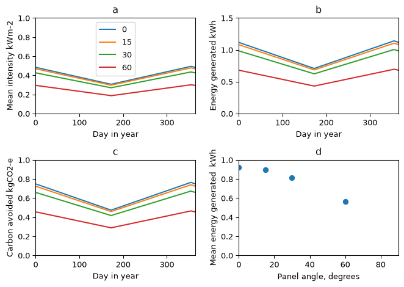

## Part B: Object Oriented Programming

### Task 6 : Create the Sun class (2 marks)

The `Sun` class models the position and seasonal strength of sunlight at a given time and date. Rather than being recalculated from scratch every time it is needed, the sun’s angle and intensity are stored as **private** state on the object, and are only updated when `calculate_angle` or `calculate_intensity` are called. **Note that the applications in the remainder of the assignment assume the sunrise time is constant, 6:00 am.** The following methods should be implemented:

- `__init__()`: A constructor to initialize the sun’s state. This method should initialise **private** attributes for the sun’s current angle and intensity, which are initially set to `None`.
- Getter methods (`get_angle()`, `get_intensity()`) to access the angle and intensity.
- `calculate_angle(hour: int, minute: int)`: A method to compute and store the sun’s angle above the horizon (in degrees), based on the time of day.
- `calculate_intensity(month: int, day: int)`: A method to compute and store the sun’s daily intensity, in kWm$^{-2}$.
- `is_up() -> bool`: A method to determine whether the sun is currently above the horizon. `True` is returned if the sun is above the horizon, and `False` otherwise.

**Note**

`calculate_angle()` and `calculate_intensity()` do not `return` a value; they store the result as a private attribute on the object, to be read later with the corresponding getter method.

For Part B, we will recycle the assumption of assignment 1: that there are 30 days in a month, and that there are 12 months in the year, amounting to 360 days per year.

An implementation in the console is given below.

sun = Sun()

print(sun.get_angle())

None

sun.calculate_angle(6, 0)

sun.get_angle()

np.float64(0.0)

sun.is_up()

np.False_

sun.calculate_angle(9, 0)

sun.get_angle()

np.float64(45.0)

sun.is_up()

np.True_

sun.calculate_intensity(3, 21)

sun.get_intensity()

0.8125

sun.calculate_intensity(12, 21)

sun.get_intensity()

1.0

### Task 7 : Create the SolarPanel class (2 marks)

The `SolarPanel` class represents a single physical solar panel, mounted at a fixed angle. Each panel is characterised by its base efficiency, degradation rate, and price. Like the `Sun` class, the panel’s intensity and efficiency are stored as private state, computed on demand rather than recalculated from scratch by every caller that needs them. The following functionality should be implemented:

- `__init__(angle: float, efficiency_base: float,` `degradation_per_month: float, price: float)`: A constructor to initialise the panel with its base efficiency, degradation rate, price, and angle, and store them privately. The panel age should be initialised and set to zero. Private attributes for the panel’s intensity (kWm$^{-2}$) and efficiency, should be initially set to `None`.
- Getter methods to access the private attributes: `get_angle()`, `get_degradation_rate()`, `get_price()`, `get_age()`, `get_panel_intensity()`, `get_efficiency()`, and `get_efficiency_base()`.
- `calculate_panel_intensity(sun: Sun)`: A method to compute and store the intensity of sunlight hitting the panel, given a `Sun` object.
- `calculate_efficiency()`: A method to compute and store the panel’s current efficiency, accounting for age-related degradation. This is slightly different from the `solar_panel_efficiency` function in Assignment 1. See the revised formulation below that incorporates the age-related degradation.
- `power_output()`: A method to compute the panel’s instantaneous power output, in kW.
- `age_by_month(months: int = 1)`: A method to advance the panel’s age, increasing future degradation. Note that months has a default value of 1, so if no argument is provided, the panel will age by one month.

A panel’s efficiency degrades over time, based on its `degradation_per_month` rate and its current age in months. The **degradation factor** is then calculated as:

$$\text{degradation factor} = \max\left(1 - \text{degradation rate} \times \text{age in months},\ \text{minimum degradation}\right)$$

**Note**

A panel’s base efficiency never degrades below 25% of its original value, regardless of how old the panel becomes.

The panel’s **effective efficiency** is then calculated as:

$$\text{efficiency} = \text{efficiency}_{\text{base}} \cdot \text{degradation factor}$$

**Note**

Degradation scales the panel’s *base* efficiency only. Note that this is different from the formula in Assignment 1, which also captures the impact of incoming sunlight on the panel efficiency.

Considering a standard 1 m x 1 m panel, the resulting DC power output is then:
$$\text{power}_{DC} [\text{kW}]= \text{panel\_intensity} [\text{kWm}^{-2}] \times 1 [m^2] \times \text{efficiency} \tag{7}$$

An implementation in the console is given below.

sun = Sun()

sun.calculate_angle(12, 0)

sun.calculate_intensity(12, 21)

panel = SolarPanel(10, 20, 0.5/12, 250)

panel.calculate_panel_intensity(sun)

panel.get_panel_intensity()

0.984807753012208

panel.calculate_efficiency() # note that this is returned as a proportion, not a percentage

panel.get_efficiency()

0.2

panel.power_output()

0.1969615506024416

panel.age_by_month(6)

panel.calculate_efficiency()

panel.get_efficiency()

0.15

panel.age_by_month(120)

panel.calculate_efficiency()

panel.get_efficiency()

0.05

panel.get_price()

250

### Task 8 : Create the Inverter class (2 marks)

The `Inverter` class represents the inverter connecting a collection of solar panels to the grid. It converts the combined DC (direct current) output of its panels into AC (alternating current) output, accounting for conversion losses and a maximum output capacity. If the combined panel DC output exceeds `Inverter`’s AC output capacity, the excess is clipped and wasted. The following functionality should be implemented:

- `__init__(efficiency: float, max_output: float, price: float)`: Initialises the inverter and privately stores the specified efficiency, maximum output capacity, and purchase price.
- `add_panel()`: A method to add a `SolarPanel` to the inverter.
- `get_panels()`: A method to return a list of all panels connected to the inverter.
- `age_panels_by_month(months: int = 1)`: advances the age of all connected panels by the specified number of months.
- `get_total_cost()`: A method to calculate the total upfront cost of the inverter and all connected panels.
- `get_num_panels()`: A method to return the number of panels connected to the inverter.
- `calculate_power_output()`: calculates the inverter’s AC power output, given a `Sun` object.

For each connected panel, the inverter sums each panel’s `power_output` to find the total DC power. This is converted to AC power by applying the inverter’s efficiency:

$$\text{power}_{AC}^{\prime} = \sum \text{power}_{DC} \cdot \text{efficiency}_{inverter}$$

The inverter cannot output more than its rated capacity, (`max_output`). The final AC output is therefore:

$$\text{power}_{AC} = \min(\text{power}_{AC}^{\prime}, \text{max\_output})$$

**Note**

Unlike `Sun` and `SolarPanel`, `calculate_power_output` **returns** the AC power output directly, rather than storing it as a private attribute to be read with a getter.

An implementation in the console is given below.

sun = Sun()

sun.calculate_angle(12, 0)

sun.calculate_intensity(12, 21)

inverter = Inverter(0.96, 1000, 600)

for _ in range(20):

inverter.add_panel(SolarPanel(10, 20, 0.5/12, 250))

inverter.get_num_panels()

20

inverter.calculate_power_output(sun)

3.7816617715668803

inverter.get_total_cost()

5600

inverter = Inverter(0.96, 2000, 600)

for _ in range(20):

inverter.add_panel(SolarPanel(10, 20, 0.5/12, 250))

inverter.calculate_power_output(sun)

3.7816617715668803

### Task 9 : Lifetime simulation (2 marks)

Having modelled the sun, individual panels, and the inverter connecting them, we can now simulate an entire solar installation’s financial and environmental performance over its operating lifetime. Write the function `simulate_lifetime(inverter, years, interval, solar_sell_price, ef_grid)`, which simulates the AC power output of an `Inverter` over a number of years, converts this into profit from selling energy to the grid, and tracks both the installation’s cumulative net benefit (profit less upfront cost) and the CO$_2$ emissions avoided over time. Building power draw is not considered — all generated energy is assumed sold to the grid at `solar_sell_price`.

At each simulated time step, energy generated (in kWh) is calculated from the inverter’s AC power output (in kW), and the interval between readings, $\Delta t$ (in minutes):

$$\text{energy} = \text{power}_{AC} \cdot \frac{\Delta t}{60}$$

The profit earned in that interval is then:
$$\text{profit} = \text{energy} \cdot \text{solar\_sell\_price}$$

The carbon saved by the solar panel (kgCO$_2$-e), is the emissions avoided by replacing grid electricity with the output of the solar panel, calculated from the product of the energy generated in that interval, and the grid emissions factor, `ef_grid` (kgCO$_2$-e per kWh):

$$\text{CO}_2\text{ savings} = \text{energy} \cdot \text{ef\_grid}$$

Profit and CO$_2$ saved are each accumulated across every interval in a day, every day in a month, and every month in a year, to give a total for each simulated year. At the end of each month, every panel connected to the inverter is aged by one month, so that degradation is reflected in subsequent months’ output.

The installation’s **net benefit** at a given point in time is its cumulative profit to date, less its total upfront cost (the inverter’s price plus the price of every connected panel):

$$\text{net benefit} = \text{cumulative profit} - \text{total upfront cost}$$

The installation’s **cumulative CO$_2$ saved** at a given point in time is simply the running total of CO$_2$ savings across every interval simulated so far:

$$\text{cumulative CO}_2\text{ saved} = \sum \text{CO}_2\text{ savings}$$

The function returns a pair of lists: net benefit, and cumulative CO$_2$ saved. Each list gives the corresponding value at the start of the simulation and again at the end of each simulated year, and so has length `years + 1`. Cumulative CO$_2$ saved begins at 0, since manufacturing emissions are not considered in this model.

```python
def simulate_lifetime(inverter: Inverter, years: int,
                      interval: int, solar_sell_price: float,
                      ef_grid: float) -> tuple[list, list]:
```

An implementation in the console is given below.

sun = Sun()

sun.calculate_angle(12, 0)

sun.calculate_intensity(12, 21)

inverter = Inverter(0.96, 2000, 1200)

for _ in range(20):

inverter.add_panel(SolarPanel(10, 20, 0.4/12, 180))

net_benefit, saved_emissions = simulate_lifetime(inverter, 10, 60, 0.2, 0.7)

len(net_benefit)

11

len(saved_emissions)

11

net_benefit

[-4800, -3719.0497992153223, -3166.816094252018, -2834.975273797023, -2503.134453342028, -2171.293632887033, -1839.452812432038, -1507.611991977043, -1175.7711715220482, -843.9303510670534, -512.0895306120585]

saved_emissions

[0.0, 3783.325702746357, 5716.143670117921, 6877.586541710398, 8039.029413302875, 9200.472284895352, 10361.915156487828, 11523.358028080305, 12684.800899672782, 13846.243771265259, 15007.686642857736]

### Task 10 : Scenario analysis (1 mark)

Using the `Sun`, `SolarPanel`, `Inverter`, and `simulate_lifetime` you have written, carry out a cost-benefit analysis comparing three solar installation scenarios over a 10 year lifetime. Write a function `simulate_solar_scenarios` which builds three `Inverter` scenarios, simulates the net benefit of each over time, and plots the results.

Two panel types are used to build the scenarios below, each specified as (efficiency_base, degradation_per_month, price):

| **Panel type** | `efficiency_base` | `degradation_per_month` | `price` |
| --- | --- | --- | --- |
| Premium | 24 | 0.01 / 12 | $120 |
| Standard | 19 | 0.10 / 12 | $80 |

Each scenario connects `num_panels` panels to an Inverter with its own efficiency, maximum output, and price. For the sample call, `num_panels = 50`:

| **Scenario** | **Panels** | **efficiency** | **max_output (W)** | **price** |
| --- | --- | --- | --- | --- |
| Premium scenario | `num_panels` × Premium | 0.98 | 5000 | $4000 |
| Budget scenario | `num_panels` × Standard | 0.94 | 3000 | $2500 |
| Mismatched scenario | `num_panels` × Premium | 0.94 | 3000 | $2500 |

The Mismatched scenario pairs premium panels with the same (lower-specification) inverter used in the Budget scenario. This illustrates that an installation’s outcome depends on the panel and inverter choices together: high-output panels connected to an undersized inverter may have their extra output clipped away rather than converted to profit.

The function produces a figure with two subplots side-by-side comparing all three scenarios:

1. **Cumulative Net Benefit (Left subplot):**
   - Include a horizontal dashed line at zero (`y = 0`) to clearly indicate the break-even point where net benefit becomes positive.
2. **Cumulative CO$_2$ Saved (Right subplot):**

The remaining simulation parameters are fed directly into the function as arguments: `years`, `interval`, `solar_sell_price`, `ef_grid`, `num_panels`, and `panel_angle`. This function does not return anything. See the function description below:

```python
def simulate_solar_scenarios(years: int, interval: int,
                             solar_sell_price: float, ef_grid: float,
                             num_panels: int, panel_angle: float):
```

The sample usage of the function is shown below:

simulate_solar_scenarios(10, 60, 0.2, 0.7, 50, 10)

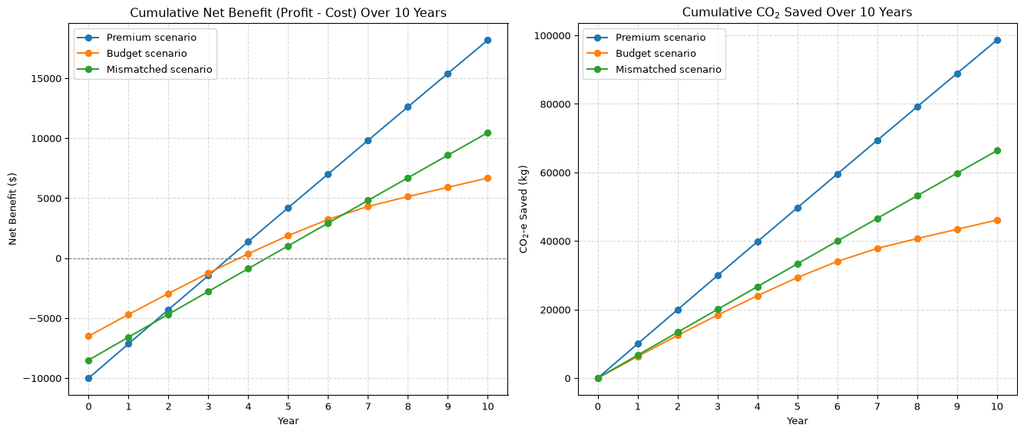

# Writing Your Code

When you submit your assignment to Gradescope you must submit only one code file and **it must be called a2.py**, also ensure that you submit the required `ai_statement.pdf` file (more details below). Do not submit any other code files or it can disrupt the automatic code testing program which will grade your assignments.

# Design

You are expected to use good programming practice in your code, and you must incorporate at least the functions described in the previous part of the assignment sheet.

# Assessment Marking

The maximum achievable mark for this assignment is 20 marks.

## Functionality assessment: 15 marks

The functionality will be marked out of 15. Your assignment will be put through a series of tests and your functionality mark will be automatically generated by the autograder. This grade is NOT overwritten. So if you have a syntax error in your code which causes it to fail all the tests even though the rest of your code is fine, you will still get 0 marks.

Your final functionality mark for the assignment is based on the most recent submission. Note that functionality tests are automated and so string outputs need to exactly match what is expected. **Do not leave it until the last minute** because it generally takes time to get your code to pass the tests.

## Code Style Assessment: 5 marks

The style of your assignment will be assessed by one of the tutors, and you will be marked according to the style rubric below. The style mark will be out of 5.

Your tutor will read your code and record each style violation as either **minor** or **major**, under one of the five categories listed below. Each category is then marked **independently** against the general marking band, and the five categories are **equally weighted**, so each one is worth $5 \div 5 = 1$ marks.

### General marking band

Marking band applied to each category

[output not shown]

**Note**

### Violations

Style violations by category

**Category**

**Minor**

**Major**

**Formatting**

- Line lengths (> 100 chars)
- Vertical / horizontal whitespace
- General readability
- Import statements

–

**Documentation**

- Missing sections for each docstring
- Verbosity of docstrings
- Missing comment per critical code block
- Verbosity per comment
- Unnecessary comments
- Missing docstring

**Identifier Names**

- Non-descriptive identifier names
- 1–2 letter identifier names
- Non `snake_case` identifier names
- Hardcoding literals that appear more than once
- Not using provided constants (i.e. provided in the support file)

**Logic and Modularity**

- Overly nested loops / if statements
- Unnecessary boolean checks (i.e. `if {condition} == True`)
- Fake loops (loops that run only once)
- `for` vs `while`, where one option is clearly better than the other
- Repeated code
- Inappropriate usage of library functions or methods

*Determined on a per case basis — see the note below.*

**Interface & Implementation**

- Variable declared much wider than it is used (i.e. defined at the top of a function but only used inside one branch)
- Unused parameters or leftover variables that are never read
- Relying on a name defined outside the function instead of taking it as a parameter (i.e. a function using a variable defined in `main()`)
- Nested functions (a function defined inside another function)
- Accessing/modifying another class’s private attributes from outside (i.e. `obj._data.append(x)` instead of calling a method)
- Returning a mutable internal attribute so the caller can modify it (i.e. `return self._items` instead of a copy)
- Usage of global variables

**Note**

For the **Logic and Modularity** category, issues are determined to be major or minor on a per case basis by a tutor.

## Assignment Submission

You must submit 2 files to Gradescope: `a2.py` and `ai_statement.pdf`. You will write your code solution in `a2.py` and you will write your usage of ai statement in `ai_statement.pdf`. If you **do not submit** `ai_statement.pdf`, or if the file is **empty**, you will automatically receive **0%** for the assignment, even if your code is perfect.

As such, even if you didn’t use ai for this assignment, you must declare that in your assignment statement. The layout of this statement is up to you, as it is not assessed directly. The following link is an official uq guidance on how to structure your ai statement: [UQ Library](https://guides.library.uq.edu.au/referencing/acknowledging-and-referencing-ai)

You are permitted to submit as many times as necessary to the autograder; only your final submission will be marked. We recommend submitting early and often; submit each completed task to the autograder as soon as it works.

According to the course ECP, late submissions will be penalised by 10% per day for up to 3 days. After 3 days (72 hours), you will recieve a mark of zero. Note that this assignment is not available for an extension, and that there are no exceptions.